# Weekly Sales Forecast for Big Box, Inc.

Big Box, Inc. requested a forecast of weekly sales for the individual deparments in each of its stores. The company provided the data team with three CSV files containing data related to its stores and their departments, weekly sales, and economic and weather conditions in the geographic areas where stores are located. Specifically Big Box requested a forecast of the next three months beyond the actual sales data provided.

We performed a time series analysis through the following phases:

# Time Series Analysis Phases

1. [Data Import, Validation, and Merge](https://mstuartproj.github.io/sales_forecast/Sales_Forecast_1.html)
2. [Exploratory Data Analysis: Stores, Departments, and Total Sales](https://mstuartproj.github.io/sales_forecast/Sales_Forecast_2.html)
3. [Exploratory Data Analysis: Weekly Sales](https://mstuartproj.github.io/sales_forecast/Sales_Forecast_3.html)
4. [Feature Creation and Selection](https://mstuartproj.github.io/sales_forecast/Sales_Forecast_4.html)
5. [Modeling and Prediction: Random Forest Regression](https://mstuartproj.github.io/sales_forecast/Sales_Forecast_5.html)
6. [Modeling and Prediction: SARIMA](https://mstuartproj.github.io/sales_forecast/Sales_Forecast_6.html)

[figure not shown]

# Phase 3. Exploratory Data Analysis: Weekly Sales

## Weekly Sales by Store

We plotted total weekly sales for the stores to examine sales trends over the given time period. We included the 12-week moving average to smooth out the noise of weekly fluctuations.

We noted the following patterns for some stores:

- Store 7 has a seasonal pattern with tall peaks at the winter holidays.
- Store 44 has similar tall peaks at the winter holidays as well as a trend of increasing sales.
- Store 38 does not have the holiday peaks but its sales are trending upwards.
- Store 14 has the tall holday peaks, but may have a slight decrease in sales. Further analysis should be performed on this store. Adding a regression line to the graph would be helpful.
- Store 36 appears to have decreasing sales. Again further analysis should be performed on this store.

[figure not shown]

```python
#import the required libraries
import matplotlib.pyplot as plt
import matplotlib.ticker as tick
import numpy as np
import pandas as pd
```

```python
#Read in fulldata.csv
fulldata = pd.read_csv('data_merged/fulldataset.csv', index_col = 0)
```

```python
#Function to plot total weekly sales for one store (include all depts)
def plot_weeklysales_for_onestore(allstoresdata, storenum, num_weeks_mov_avg):

    onestoredata = allstoresdata.loc[allstoresdata['Store'] == storenum]
    weeklysales = onestoredata.groupby('Date')['Weekly_Sales'].sum().to_frame().reset_index()
    weeklysales['Moving_Avg'] = weeklysales.Weekly_Sales.rolling(num_weeks_mov_avg).mean()

    plt.figure(figsize=(10, 5))
    plt.xlabel('Week')
    plt.ylabel('Weekly Sales ($)')
    plt.title('Total Weekly Sales for Store #' + str(storenum))
    plt.xticks(rotation=45)
    plt.xticks(np.arange(0, 132, 8))
    plt.plot(weeklysales['Date'],
             weeklysales['Weekly_Sales'],
             label='Weekly Sales')
    plt.plot(weeklysales['Date'],
             weeklysales['Moving_Avg'],
             label=str(num_weeks_mov_avg)+'-Week Moving Average')
    plt.legend()
    ax = plt.gca()
    ax.yaxis.set_major_formatter(tick.FuncFormatter(lambda x, p: format(int(x), ',')));
```

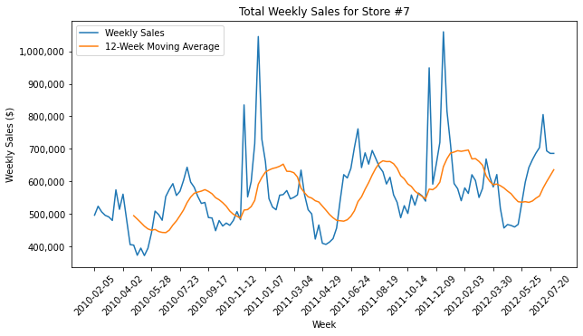

```python
onestorenum = 7
plot_weeklysales_for_onestore(fulldata, onestorenum, 12)
```

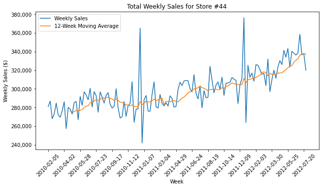

```python
onestorenum = 44
plot_weeklysales_for_onestore(fulldata, onestorenum, 12)
```

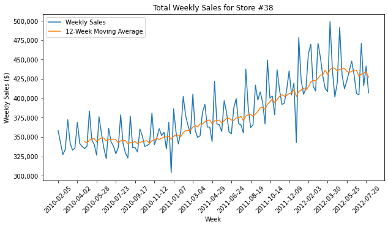

```python
onestorenum = 38
plot_weeklysales_for_onestore(fulldata, onestorenum, 12)
```

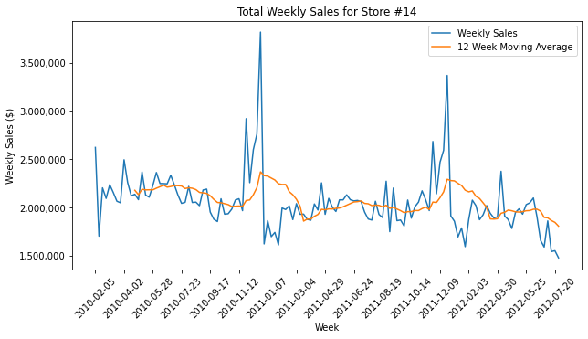

```python
onestorenum = 14
plot_weeklysales_for_onestore(fulldata, onestorenum, 12)
```

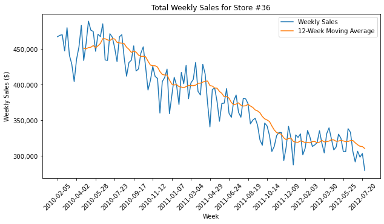

```python
onestorenum = 36
plot_weeklysales_for_onestore(fulldata, onestorenum, 12)
```

[figure not shown]

## Weekly Sales of One Department in One Store

We plotted weekly sales for single departments in individual stores to examine sales trends over the given time period. Again we include the 12-week moving average to smooth out the noise of weekly fluctuations.

We noted the following patterns:

- **Store 1 Department 1** has sales peaks surrounding these four times of year:
  - Late October or early Nomber
  - Late December
  - Mid February
  - Early April
- **Store 5 Department 26** has seasonal sales that are lowest in the summer months, highest in the winter months, with peaks at the winter holidays.
- **Store 33 Department 80** does not appear to have seasonal sales, however its sales are trending downwards. Again further analysis should be performed on this department.

[figure not shown]

```python
#Function to plot total weekly sales for one dept in one store
def plot_weeklysales_for_onedept(allstoresdata, storenum, deptnum, num_weeks_mov_avg):

    thedept = (allstoresdata["Store"] == storenum) & (allstoresdata["Dept"] == deptnum)
    onedeptdata = allstoresdata.loc[thedept]
    weeklysales = onedeptdata.groupby('Date')['Weekly_Sales'].sum().to_frame().reset_index()
    weeklysales['Moving_Avg'] = weeklysales.Weekly_Sales.rolling(num_weeks_mov_avg).mean()

    plt.figure(figsize=(10, 5))
    plt.xlabel('Week')
    plt.ylabel('Weekly Sales ($)')
    plt.title('Total Weekly Sales for Store #' + str(storenum) + ' Dept #' + str(deptnum))
    plt.xticks(rotation=45)
    plt.xticks(np.arange(0, 132, 8))
    plt.plot(weeklysales['Date'],
             weeklysales['Weekly_Sales'],
             label='Weekly Sales')
    plt.plot(weeklysales['Date'],
             weeklysales['Moving_Avg'],
             label=str(num_weeks_mov_avg)+'-Week Moving Average')
    plt.legend()
    ax = plt.gca()
    ax.yaxis.set_major_formatter(tick.FuncFormatter(lambda x, p: format(int(x), ',')));
```

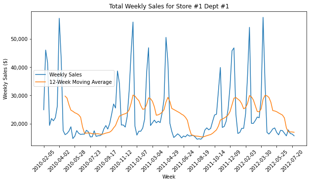

```python
onestorenum = 1
onedeptnum = 1
plot_weeklysales_for_onedept(fulldata, onestorenum, onedeptnum, 12)
```

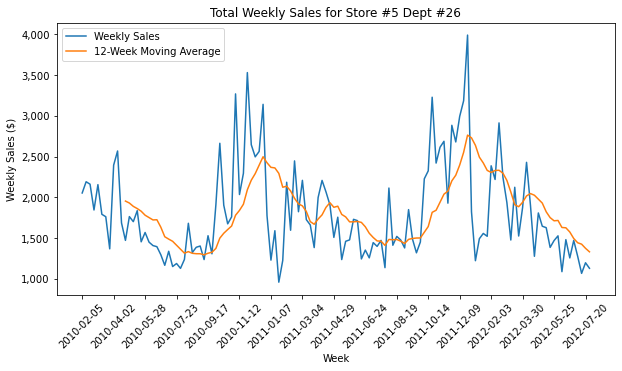

```python
onestorenum = 5
onedeptnum = 26
plot_weeklysales_for_onedept(fulldata, onestorenum, onedeptnum, 12)
```

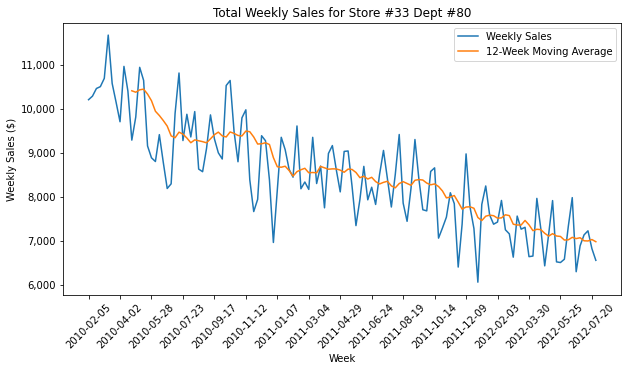

```python
onestorenum = 33
onedeptnum = 80
plot_weeklysales_for_onedept(fulldata, onestorenum, onedeptnum, 12)
```